# Risk Factor Analysis

## Outcome Variable

**Outcome Variable:** stunted

## Predictor Variables

**Intervention Variable:** predfeed6

**Adjustment Set:**

- arm
- sex
- month
- brthmon
- W_mage
- meducyrs
- feducyrs
- hhwealth_quart
- hfoodsec
- W_mhtcm
- W_mwtkg
- W_mbmi
- vagbrth
- W_gagebrth
- W_birthwt
- W_birthlen
- W_nrooms
- W_nchldlt5
- W_parity
- impfloor
- impsan
- safeh20
- delta_W_mage
- delta_meducyrs
- delta_feducyrs
- delta_hhwealth_quart
- delta_hfoodsec
- delta_W_mhtcm
- delta_W_mwtkg
- delta_W_mbmi
- delta_vagbrth
- delta_W_gagebrth
- delta_W_birthwt
- delta_W_birthlen
- delta_W_nrooms
- delta_W_nchldlt5
- delta_W_parity
- delta_impfloor
- delta_impsan
- delta_safeh20

## Stratifying Variables

The analysis was stratified on these variable(s):

- agecat
- studyid
- country

## Data Summary

| agecat | studyid | country | predfeed6 | stunted | n_cell | n |
| --- | --- | --- | --- | --- | --- | --- |
| Birth | ki0047075b-MAL-ED | BANGLADESH | 1 | 0 | 60 | 205 |
| Birth | ki0047075b-MAL-ED | BANGLADESH | 1 | 1 | 12 | 205 |
| Birth | ki0047075b-MAL-ED | BANGLADESH | 0 | 0 | 109 | 205 |
| Birth | ki0047075b-MAL-ED | BANGLADESH | 0 | 1 | 24 | 205 |
| Birth | ki0047075b-MAL-ED | BRAZIL | 1 | 0 | 4 | 60 |
| Birth | ki0047075b-MAL-ED | BRAZIL | 1 | 1 | 2 | 60 |
| Birth | ki0047075b-MAL-ED | BRAZIL | 0 | 0 | 47 | 60 |
| Birth | ki0047075b-MAL-ED | BRAZIL | 0 | 1 | 7 | 60 |
| Birth | ki0047075b-MAL-ED | INDIA | 1 | 0 | 2 | 39 |
| Birth | ki0047075b-MAL-ED | INDIA | 1 | 1 | 2 | 39 |
| Birth | ki0047075b-MAL-ED | INDIA | 0 | 0 | 29 | 39 |
| Birth | ki0047075b-MAL-ED | INDIA | 0 | 1 | 6 | 39 |
| Birth | ki0047075b-MAL-ED | NEPAL | 1 | 0 | 3 | 24 |
| Birth | ki0047075b-MAL-ED | NEPAL | 1 | 1 | 0 | 24 |
| Birth | ki0047075b-MAL-ED | NEPAL | 0 | 0 | 20 | 24 |
| Birth | ki0047075b-MAL-ED | NEPAL | 0 | 1 | 1 | 24 |
| Birth | ki0047075b-MAL-ED | PERU | 1 | 0 | 66 | 213 |
| Birth | ki0047075b-MAL-ED | PERU | 1 | 1 | 7 | 213 |
| Birth | ki0047075b-MAL-ED | PERU | 0 | 0 | 121 | 213 |
| Birth | ki0047075b-MAL-ED | PERU | 0 | 1 | 19 | 213 |
| Birth | ki0047075b-MAL-ED | SOUTH AFRICA | 1 | 0 | 1 | 91 |
| Birth | ki0047075b-MAL-ED | SOUTH AFRICA | 1 | 1 | 0 | 91 |
| Birth | ki0047075b-MAL-ED | SOUTH AFRICA | 0 | 0 | 82 | 91 |
| Birth | ki0047075b-MAL-ED | SOUTH AFRICA | 0 | 1 | 8 | 91 |
| Birth | ki0047075b-MAL-ED | TANZANIA, UNITED REPUBLIC OF | 1 | 0 | 0 | 113 |
| Birth | ki0047075b-MAL-ED | TANZANIA, UNITED REPUBLIC OF | 1 | 1 | 0 | 113 |
| Birth | ki0047075b-MAL-ED | TANZANIA, UNITED REPUBLIC OF | 0 | 0 | 92 | 113 |
| Birth | ki0047075b-MAL-ED | TANZANIA, UNITED REPUBLIC OF | 0 | 1 | 21 | 113 |
| Birth | ki1000109-EE | PAKISTAN | 1 | 0 | 22 | 42 |
| Birth | ki1000109-EE | PAKISTAN | 1 | 1 | 16 | 42 |

[output cut: 114 more lines]

The following strata were considered:

- agecat: 24 months, studyid: ki0047075b-MAL-ED, country: BANGLADESH
- agecat: 24 months, studyid: ki0047075b-MAL-ED, country: BRAZIL
- agecat: 24 months, studyid: ki0047075b-MAL-ED, country: INDIA
- agecat: 24 months, studyid: ki0047075b-MAL-ED, country: NEPAL
- agecat: 24 months, studyid: ki0047075b-MAL-ED, country: PERU
- agecat: 24 months, studyid: ki0047075b-MAL-ED, country: SOUTH AFRICA
- agecat: 24 months, studyid: ki0047075b-MAL-ED, country: TANZANIA, UNITED REPUBLIC OF
- agecat: 24 months, studyid: ki1000109-EE, country: PAKISTAN
- agecat: 24 months, studyid: ki1113344-GMS-Nepal, country: NEPAL
- agecat: 24 months, studyid: ki1148112-LCNI-5, country: MALAWI
- agecat: 24 months, studyid: kiGH5241-JiVitA-3, country: BANGLADESH
- agecat: 24 months, studyid: kiGH5241-JiVitA-4, country: BANGLADESH
- agecat: 6 months, studyid: ki0047075b-MAL-ED, country: BANGLADESH
- agecat: 6 months, studyid: ki0047075b-MAL-ED, country: BRAZIL
- agecat: 6 months, studyid: ki0047075b-MAL-ED, country: INDIA
- agecat: 6 months, studyid: ki0047075b-MAL-ED, country: NEPAL
- agecat: 6 months, studyid: ki0047075b-MAL-ED, country: PERU
- agecat: 6 months, studyid: ki0047075b-MAL-ED, country: SOUTH AFRICA
- agecat: 6 months, studyid: ki0047075b-MAL-ED, country: TANZANIA, UNITED REPUBLIC OF
- agecat: 6 months, studyid: ki1000109-EE, country: PAKISTAN
- agecat: 6 months, studyid: ki1000304b-SAS-FoodSuppl, country: INDIA
- agecat: 6 months, studyid: ki1113344-GMS-Nepal, country: NEPAL
- agecat: 6 months, studyid: ki1148112-LCNI-5, country: MALAWI
- agecat: 6 months, studyid: kiGH5241-JiVitA-3, country: BANGLADESH
- agecat: 6 months, studyid: kiGH5241-JiVitA-4, country: BANGLADESH
- agecat: Birth, studyid: ki0047075b-MAL-ED, country: BANGLADESH
- agecat: Birth, studyid: ki0047075b-MAL-ED, country: BRAZIL
- agecat: Birth, studyid: ki0047075b-MAL-ED, country: INDIA
- agecat: Birth, studyid: ki0047075b-MAL-ED, country: NEPAL
- agecat: Birth, studyid: ki0047075b-MAL-ED, country: PERU
- agecat: Birth, studyid: ki0047075b-MAL-ED, country: SOUTH AFRICA
- agecat: Birth, studyid: ki0047075b-MAL-ED, country: TANZANIA, UNITED REPUBLIC OF
- agecat: Birth, studyid: ki1000109-EE, country: PAKISTAN
- agecat: Birth, studyid: ki1113344-GMS-Nepal, country: NEPAL
- agecat: Birth, studyid: kiGH5241-JiVitA-3, country: BANGLADESH
- agecat: Birth, studyid: kiGH5241-JiVitA-4, country: BANGLADESH

### Dropped Strata

Some strata were dropped due to rare outcomes:

- agecat: Birth, studyid: ki0047075b-MAL-ED, country: BRAZIL
- agecat: Birth, studyid: ki0047075b-MAL-ED, country: INDIA
- agecat: Birth, studyid: ki0047075b-MAL-ED, country: NEPAL
- agecat: Birth, studyid: ki0047075b-MAL-ED, country: SOUTH AFRICA
- agecat: Birth, studyid: ki0047075b-MAL-ED, country: TANZANIA, UNITED REPUBLIC OF
- agecat: Birth, studyid: ki1000109-EE, country: PAKISTAN
- agecat: 6 months, studyid: ki0047075b-MAL-ED, country: BRAZIL
- agecat: 6 months, studyid: ki0047075b-MAL-ED, country: INDIA
- agecat: 6 months, studyid: ki0047075b-MAL-ED, country: NEPAL
- agecat: 6 months, studyid: ki0047075b-MAL-ED, country: SOUTH AFRICA
- agecat: 6 months, studyid: ki0047075b-MAL-ED, country: TANZANIA, UNITED REPUBLIC OF
- agecat: 6 months, studyid: ki1000109-EE, country: PAKISTAN
- agecat: 6 months, studyid: ki1000304b-SAS-FoodSuppl, country: INDIA
- agecat: 24 months, studyid: ki0047075b-MAL-ED, country: BRAZIL
- agecat: 24 months, studyid: ki0047075b-MAL-ED, country: INDIA
- agecat: 24 months, studyid: ki0047075b-MAL-ED, country: NEPAL
- agecat: 24 months, studyid: ki0047075b-MAL-ED, country: SOUTH AFRICA
- agecat: 24 months, studyid: ki0047075b-MAL-ED, country: TANZANIA, UNITED REPUBLIC OF
- agecat: 24 months, studyid: ki1000109-EE, country: PAKISTAN

## Methods Detail

We’re interested in the causal parameters $E[Y_a]$ for all values of $a \in \mathcal{A}$. These parameters represent the mean outcome if, possibly contrary to fact, we intervened to set all units to have $A=a$. Under the randomization and positivity assumptions, these are identified by the statistical parameters $\psi_a=E_W[E_{Y|A,W}(Y|A=a,W)]$. In addition, we’re interested in the mean of $Y$, $E[Y]$ under no intervention (the observed mean). We will estimate these parameters by using SuperLearner to fit the relevant likelihood factors – $E_{Y|A,W}(Y|A=a,W)$ and $p(A=a|W)$, and then updating our likelihood fit using a joint TMLE.

For unadjusted analyses ($W=\{\}$), initial likelihoods were estimated using Lrnr_glm to estimate the simple $E(Y|A)$ and Lrnr_mean to estimate $p(A)$. For adjusted analyses, a small library containing Lrnr_glmnet, Lrnr_xgboost, and Lrnr_mean was used.

Having estimated these parameters, we will then use the delta method to estimate relative risks and attributable risks relative to a prespecified baseline level of $A$.

# Results Detail

## Results Plots

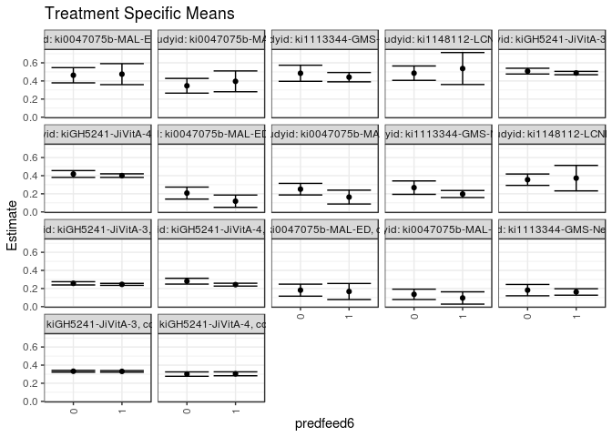

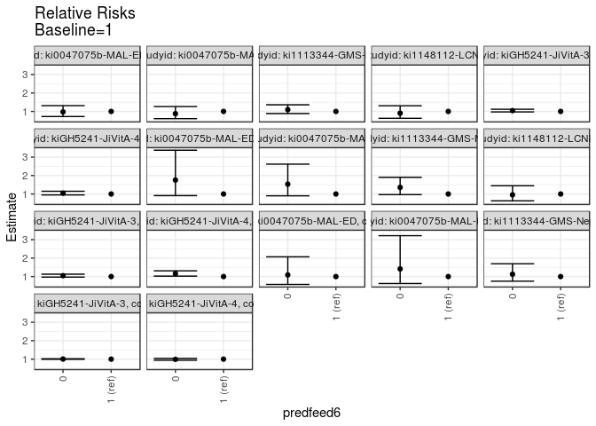

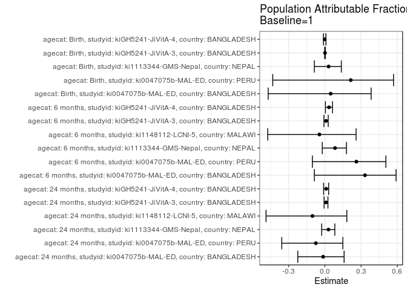

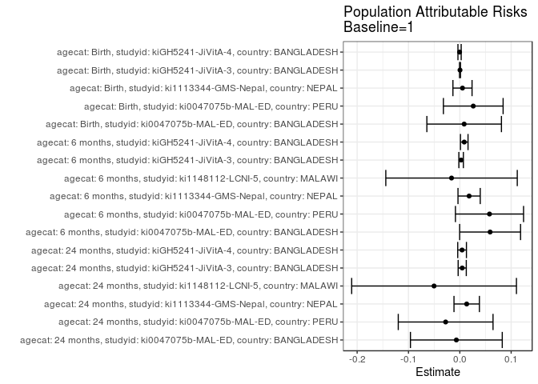

## Results Table

### Parameter: TSM

| agecat | studyid | country | intervention_level | baseline_level | estimate | ci_lower | ci_upper |
| --- | --- | --- | --- | --- | --- | --- | --- |
| Birth | ki0047075b-MAL-ED | BANGLADESH | 1 | NA | 0.1671649 | 0.0785000 | 0.2558298 |
| Birth | ki0047075b-MAL-ED | BANGLADESH | 0 | NA | 0.1819437 | 0.1155445 | 0.2483429 |
| Birth | ki0047075b-MAL-ED | PERU | 1 | NA | 0.0958904 | 0.0281876 | 0.1635932 |
| Birth | ki0047075b-MAL-ED | PERU | 0 | NA | 0.1357143 | 0.0788490 | 0.1925796 |
| Birth | ki1113344-GMS-Nepal | NEPAL | 1 | NA | 0.1617696 | 0.1262947 | 0.1972445 |
| Birth | ki1113344-GMS-Nepal | NEPAL | 0 | NA | 0.1822547 | 0.1195510 | 0.2449584 |
| Birth | kiGH5241-JiVitA-3 | BANGLADESH | 1 | NA | 0.3307119 | 0.3214618 | 0.3399619 |
| Birth | kiGH5241-JiVitA-3 | BANGLADESH | 0 | NA | 0.3323960 | 0.3226140 | 0.3421780 |
| Birth | kiGH5241-JiVitA-4 | BANGLADESH | 1 | NA | 0.3040569 | 0.2825122 | 0.3256016 |
| Birth | kiGH5241-JiVitA-4 | BANGLADESH | 0 | NA | 0.3010380 | 0.2768624 | 0.3252136 |
| 6 months | ki0047075b-MAL-ED | BANGLADESH | 1 | NA | 0.1184836 | 0.0505989 | 0.1863683 |
| 6 months | ki0047075b-MAL-ED | BANGLADESH | 0 | NA | 0.2079894 | 0.1418914 | 0.2740875 |
| 6 months | ki0047075b-MAL-ED | PERU | 1 | NA | 0.1635957 | 0.0869903 | 0.2402010 |
| 6 months | ki0047075b-MAL-ED | PERU | 0 | NA | 0.2512045 | 0.1873685 | 0.3150406 |
| 6 months | ki1113344-GMS-Nepal | NEPAL | 1 | NA | 0.1976118 | 0.1587818 | 0.2364419 |
| 6 months | ki1113344-GMS-Nepal | NEPAL | 0 | NA | 0.2680693 | 0.1940230 | 0.3421156 |
| 6 months | ki1148112-LCNI-5 | MALAWI | 1 | NA | 0.3727495 | 0.2320815 | 0.5134175 |
| 6 months | ki1148112-LCNI-5 | MALAWI | 0 | NA | 0.3556125 | 0.2928824 | 0.4183426 |
| 6 months | kiGH5241-JiVitA-3 | BANGLADESH | 1 | NA | 0.2457469 | 0.2348007 | 0.2566931 |
| 6 months | kiGH5241-JiVitA-3 | BANGLADESH | 0 | NA | 0.2572717 | 0.2392935 | 0.2752498 |
| 6 months | kiGH5241-JiVitA-4 | BANGLADESH | 1 | NA | 0.2425544 | 0.2266603 | 0.2584486 |
| 6 months | kiGH5241-JiVitA-4 | BANGLADESH | 0 | NA | 0.2810667 | 0.2491362 | 0.3129973 |
| 24 months | ki0047075b-MAL-ED | BANGLADESH | 1 | NA | 0.4750497 | 0.3592321 | 0.5908672 |
| 24 months | ki0047075b-MAL-ED | BANGLADESH | 0 | NA | 0.4629710 | 0.3790808 | 0.5468613 |
| 24 months | ki0047075b-MAL-ED | PERU | 1 | NA | 0.3957712 | 0.2809960 | 0.5105463 |
| 24 months | ki0047075b-MAL-ED | PERU | 0 | NA | 0.3468687 | 0.2657327 | 0.4280048 |
| 24 months | ki1113344-GMS-Nepal | NEPAL | 1 | NA | 0.4419225 | 0.3903881 | 0.4934568 |
| 24 months | ki1113344-GMS-Nepal | NEPAL | 0 | NA | 0.4849471 | 0.3962058 | 0.5736884 |
| 24 months | ki1148112-LCNI-5 | MALAWI | 1 | NA | 0.5369522 | 0.3604538 | 0.7134505 |
| 24 months | ki1148112-LCNI-5 | MALAWI | 0 | NA | 0.4859522 | 0.4067666 | 0.5651377 |
| 24 months | kiGH5241-JiVitA-3 | BANGLADESH | 1 | NA | 0.4874640 | 0.4687817 | 0.5061462 |
| 24 months | kiGH5241-JiVitA-3 | BANGLADESH | 0 | NA | 0.5084006 | 0.4765699 | 0.5402314 |
| 24 months | kiGH5241-JiVitA-4 | BANGLADESH | 1 | NA | 0.4006884 | 0.3810273 | 0.4203495 |
| 24 months | kiGH5241-JiVitA-4 | BANGLADESH | 0 | NA | 0.4185143 | 0.3810437 | 0.4559850 |

### Parameter: E(Y)

| agecat | studyid | country | intervention_level | baseline_level | estimate | ci_lower | ci_upper |
| --- | --- | --- | --- | --- | --- | --- | --- |
| Birth | ki0047075b-MAL-ED | BANGLADESH | NA | NA | 0.1756098 | 0.1233973 | 0.2278222 |
| Birth | ki0047075b-MAL-ED | PERU | NA | NA | 0.1220657 | 0.0779993 | 0.1661322 |
| Birth | ki1113344-GMS-Nepal | NEPAL | NA | NA | 0.1669627 | 0.1361293 | 0.1977961 |
| Birth | kiGH5241-JiVitA-3 | BANGLADESH | NA | NA | 0.3310735 | 0.3218922 | 0.3402548 |
| Birth | kiGH5241-JiVitA-4 | BANGLADESH | NA | NA | 0.3035714 | 0.2824097 | 0.3247332 |
| 6 months | ki0047075b-MAL-ED | BANGLADESH | NA | NA | 0.1774892 | 0.1281103 | 0.2268680 |
| 6 months | ki0047075b-MAL-ED | PERU | NA | NA | 0.2214022 | 0.1718784 | 0.2709260 |
| 6 months | ki1113344-GMS-Nepal | NEPAL | NA | NA | 0.2157221 | 0.1812209 | 0.2502233 |
| 6 months | ki1148112-LCNI-5 | MALAWI | NA | NA | 0.3566176 | 0.2995882 | 0.4136471 |
| 6 months | kiGH5241-JiVitA-3 | BANGLADESH | NA | NA | 0.2482578 | 0.2382387 | 0.2582768 |
| 6 months | kiGH5241-JiVitA-4 | BANGLADESH | NA | NA | 0.2511704 | 0.2362353 | 0.2661055 |
| 24 months | ki0047075b-MAL-ED | BANGLADESH | NA | NA | 0.4682927 | 0.3998183 | 0.5367670 |
| 24 months | ki0047075b-MAL-ED | PERU | NA | NA | 0.3681592 | 0.3013164 | 0.4350020 |
| 24 months | ki1113344-GMS-Nepal | NEPAL | NA | NA | 0.4553191 | 0.4102488 | 0.5003895 |
| 24 months | ki1148112-LCNI-5 | MALAWI | NA | NA | 0.4867725 | 0.4153250 | 0.5582200 |
| 24 months | kiGH5241-JiVitA-3 | BANGLADESH | NA | NA | 0.4921384 | 0.4750959 | 0.5091808 |
| 24 months | kiGH5241-JiVitA-4 | BANGLADESH | NA | NA | 0.4050965 | 0.3867240 | 0.4234689 |

### Parameter: RR

| agecat | studyid | country | intervention_level | baseline_level | estimate | ci_lower | ci_upper |
| --- | --- | --- | --- | --- | --- | --- | --- |
| Birth | ki0047075b-MAL-ED | BANGLADESH | 1 | 1 | 1.0000000 | 1.0000000 | 1.000000 |
| Birth | ki0047075b-MAL-ED | BANGLADESH | 0 | 1 | 1.0884086 | 0.5721498 | 2.070495 |
| Birth | ki0047075b-MAL-ED | PERU | 1 | 1 | 1.0000000 | 1.0000000 | 1.000000 |
| Birth | ki0047075b-MAL-ED | PERU | 0 | 1 | 1.4153061 | 0.6227136 | 3.216714 |
| Birth | ki1113344-GMS-Nepal | NEPAL | 1 | 1 | 1.0000000 | 1.0000000 | 1.000000 |
| Birth | ki1113344-GMS-Nepal | NEPAL | 0 | 1 | 1.1266310 | 0.7485953 | 1.695572 |
| Birth | kiGH5241-JiVitA-3 | BANGLADESH | 1 | 1 | 1.0000000 | 1.0000000 | 1.000000 |
| Birth | kiGH5241-JiVitA-3 | BANGLADESH | 0 | 1 | 1.0050926 | 0.9917934 | 1.018570 |
| Birth | kiGH5241-JiVitA-4 | BANGLADESH | 1 | 1 | 1.0000000 | 1.0000000 | 1.000000 |
| Birth | kiGH5241-JiVitA-4 | BANGLADESH | 0 | 1 | 0.9900712 | 0.9395996 | 1.043254 |
| 6 months | ki0047075b-MAL-ED | BANGLADESH | 1 | 1 | 1.0000000 | 1.0000000 | 1.000000 |
| 6 months | ki0047075b-MAL-ED | BANGLADESH | 0 | 1 | 1.7554285 | 0.9133331 | 3.373938 |
| 6 months | ki0047075b-MAL-ED | PERU | 1 | 1 | 1.0000000 | 1.0000000 | 1.000000 |
| 6 months | ki0047075b-MAL-ED | PERU | 0 | 1 | 1.5355206 | 0.9010059 | 2.616879 |
| 6 months | ki1113344-GMS-Nepal | NEPAL | 1 | 1 | 1.0000000 | 1.0000000 | 1.000000 |
| 6 months | ki1113344-GMS-Nepal | NEPAL | 0 | 1 | 1.3565448 | 0.9661074 | 1.904771 |
| 6 months | ki1148112-LCNI-5 | MALAWI | 1 | 1 | 1.0000000 | 1.0000000 | 1.000000 |
| 6 months | ki1148112-LCNI-5 | MALAWI | 0 | 1 | 0.9540254 | 0.6288687 | 1.447304 |
| 6 months | kiGH5241-JiVitA-3 | BANGLADESH | 1 | 1 | 1.0000000 | 1.0000000 | 1.000000 |
| 6 months | kiGH5241-JiVitA-3 | BANGLADESH | 0 | 1 | 1.0468971 | 0.9702506 | 1.129598 |
| 6 months | kiGH5241-JiVitA-4 | BANGLADESH | 1 | 1 | 1.0000000 | 1.0000000 | 1.000000 |
| 6 months | kiGH5241-JiVitA-4 | BANGLADESH | 0 | 1 | 1.1587780 | 1.0238495 | 1.311488 |
| 24 months | ki0047075b-MAL-ED | BANGLADESH | 1 | 1 | 1.0000000 | 1.0000000 | 1.000000 |
| 24 months | ki0047075b-MAL-ED | BANGLADESH | 0 | 1 | 0.9745740 | 0.7233389 | 1.313070 |
| 24 months | ki0047075b-MAL-ED | PERU | 1 | 1 | 1.0000000 | 1.0000000 | 1.000000 |
| 24 months | ki0047075b-MAL-ED | PERU | 0 | 1 | 0.8764376 | 0.6070342 | 1.265403 |
| 24 months | ki1113344-GMS-Nepal | NEPAL | 1 | 1 | 1.0000000 | 1.0000000 | 1.000000 |
| 24 months | ki1113344-GMS-Nepal | NEPAL | 0 | 1 | 1.0973579 | 0.8856358 | 1.359695 |
| 24 months | ki1148112-LCNI-5 | MALAWI | 1 | 1 | 1.0000000 | 1.0000000 | 1.000000 |
| 24 months | ki1148112-LCNI-5 | MALAWI | 0 | 1 | 0.9050194 | 0.6264512 | 1.307460 |
| 24 months | kiGH5241-JiVitA-3 | BANGLADESH | 1 | 1 | 1.0000000 | 1.0000000 | 1.000000 |
| 24 months | kiGH5241-JiVitA-3 | BANGLADESH | 0 | 1 | 1.0429502 | 0.9737172 | 1.117106 |
| 24 months | kiGH5241-JiVitA-4 | BANGLADESH | 1 | 1 | 1.0000000 | 1.0000000 | 1.000000 |
| 24 months | kiGH5241-JiVitA-4 | BANGLADESH | 0 | 1 | 1.0444882 | 0.9499071 | 1.148487 |

### Parameter: PAR

| agecat | studyid | country | intervention_level | baseline_level | estimate | ci_lower | ci_upper |
| --- | --- | --- | --- | --- | --- | --- | --- |
| Birth | ki0047075b-MAL-ED | BANGLADESH | 1 | NA | 0.0084448 | -0.0641861 | 0.0810758 |
| Birth | ki0047075b-MAL-ED | PERU | 1 | NA | 0.0261753 | -0.0319940 | 0.0843446 |
| Birth | ki1113344-GMS-Nepal | NEPAL | 1 | NA | 0.0051931 | -0.0134381 | 0.0238242 |
| Birth | kiGH5241-JiVitA-3 | BANGLADESH | 1 | NA | 0.0003617 | -0.0006124 | 0.0013357 |
| Birth | kiGH5241-JiVitA-4 | BANGLADESH | 1 | NA | -0.0004855 | -0.0036545 | 0.0026836 |
| 6 months | ki0047075b-MAL-ED | BANGLADESH | 1 | NA | 0.0590056 | -0.0003065 | 0.1183177 |
| 6 months | ki0047075b-MAL-ED | PERU | 1 | NA | 0.0578065 | -0.0085449 | 0.1241580 |
| 6 months | ki1113344-GMS-Nepal | NEPAL | 1 | NA | 0.0181103 | -0.0035653 | 0.0397859 |
| 6 months | ki1148112-LCNI-5 | MALAWI | 1 | NA | -0.0161318 | -0.1441813 | 0.1119176 |
| 6 months | kiGH5241-JiVitA-3 | BANGLADESH | 1 | NA | 0.0025109 | -0.0019033 | 0.0069250 |
| 6 months | kiGH5241-JiVitA-4 | BANGLADESH | 1 | NA | 0.0086160 | 0.0012419 | 0.0159900 |
| 24 months | ki0047075b-MAL-ED | BANGLADESH | 1 | NA | -0.0067570 | -0.0961876 | 0.0826737 |
| 24 months | ki0047075b-MAL-ED | PERU | 1 | NA | -0.0276120 | -0.1199093 | 0.0646853 |
| 24 months | ki1113344-GMS-Nepal | NEPAL | 1 | NA | 0.0133967 | -0.0113539 | 0.0381472 |
| 24 months | ki1148112-LCNI-5 | MALAWI | 1 | NA | -0.0501797 | -0.2106642 | 0.1103048 |
| 24 months | kiGH5241-JiVitA-3 | BANGLADESH | 1 | NA | 0.0046744 | -0.0032458 | 0.0125946 |
| 24 months | kiGH5241-JiVitA-4 | BANGLADESH | 1 | NA | 0.0044080 | -0.0040650 | 0.0128810 |

### Parameter: PAF

| agecat | studyid | country | intervention_level | baseline_level | estimate | ci_lower | ci_upper |
| --- | --- | --- | --- | --- | --- | --- | --- |
| Birth | ki0047075b-MAL-ED | BANGLADESH | 1 | NA | 0.0480887 | -0.4698879 | 0.3835345 |
| Birth | ki0047075b-MAL-ED | PERU | 1 | NA | 0.2144362 | -0.4318688 | 0.5690175 |
| Birth | ki1113344-GMS-Nepal | NEPAL | 1 | NA | 0.0311032 | -0.0871106 | 0.1364623 |
| Birth | kiGH5241-JiVitA-3 | BANGLADESH | 1 | NA | 0.0010924 | -0.0018547 | 0.0040309 |
| Birth | kiGH5241-JiVitA-4 | BANGLADESH | 1 | NA | -0.0015991 | -0.0120882 | 0.0087812 |
| 6 months | ki0047075b-MAL-ED | BANGLADESH | 1 | NA | 0.3324462 | -0.0871770 | 0.5901053 |
| 6 months | ki0047075b-MAL-ED | PERU | 1 | NA | 0.2610928 | -0.1038582 | 0.5053859 |
| 6 months | ki1113344-GMS-Nepal | NEPAL | 1 | NA | 0.0839519 | -0.0217184 | 0.1786934 |
| 6 months | ki1148112-LCNI-5 | MALAWI | 1 | NA | -0.0452357 | -0.4736958 | 0.2586546 |
| 6 months | kiGH5241-JiVitA-3 | BANGLADESH | 1 | NA | 0.0101140 | -0.0078317 | 0.0277402 |
| 6 months | kiGH5241-JiVitA-4 | BANGLADESH | 1 | NA | 0.0343033 | 0.0046580 | 0.0630657 |
| 24 months | ki0047075b-MAL-ED | BANGLADESH | 1 | NA | -0.0144290 | -0.2244224 | 0.1595497 |
| 24 months | ki0047075b-MAL-ED | PERU | 1 | NA | -0.0750001 | -0.3575504 | 0.1487423 |
| 24 months | ki1113344-GMS-Nepal | NEPAL | 1 | NA | 0.0294226 | -0.0265859 | 0.0823754 |
| 24 months | ki1148112-LCNI-5 | MALAWI | 1 | NA | -0.1030866 | -0.4875536 | 0.1820127 |
| 24 months | kiGH5241-JiVitA-3 | BANGLADESH | 1 | NA | 0.0094982 | -0.0067249 | 0.0254598 |
| 24 months | kiGH5241-JiVitA-4 | BANGLADESH | 1 | NA | 0.0108815 | -0.0102263 | 0.0315482 |